# Homework-06: Correlation And Regression Homework

Andrew Judell-Halfpenny

# Github url of Rmd and HTML files

> https://github.com/ahalfpen727/BIOL607-Intro-to-Biological-Data-Analysis/blob/master/Homework/HW_06_Judell_Halfpenny_Andrew_2018.html https://github.com/ahalfpen727/BIOL607-Intro-to-Biological-Data-Analysis/blob/master/Homework/HW_06_Judell_Halfpenny_Andrew_2018.Rmd

# 1. Correlation - W&S Chapter 16

## > Question 15 and 19

# 15) Does learning a second language change brain structure? Mechelli et al. (2004) tested 22 native Italian speakers who had learned English as a second language. Proficiencies in reading, writing, and speech were assessed using a number of tests whose results were summarized by a proficiency score. Gray-matter density was measured in the left inferior parietal region of the brain using a neuroimaging technique, as mm3 of gray matter per voxel. (A voxel is a picture element, or “pixel,” in three dimensions.) The data are listed in the accompanying table.

# 15.a) Display the association between the two variables in a scatter plot.

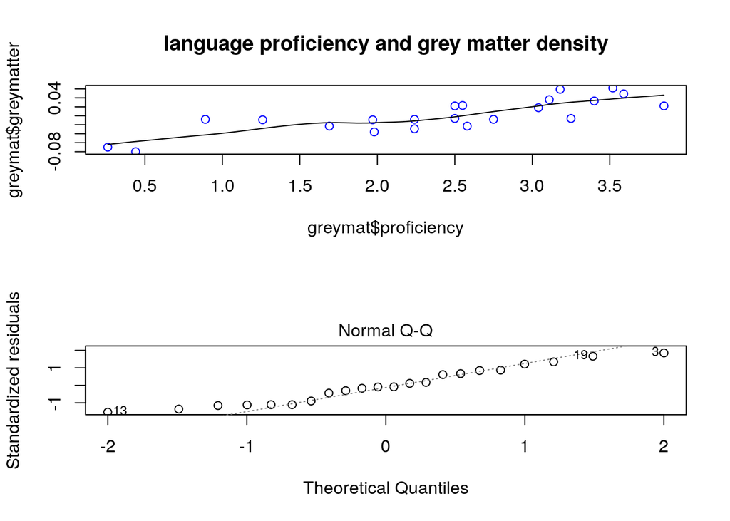

```r
greymat<-read.csv("http://whitlockschluter.zoology.ubc.ca/wp-content/data/chapter16/chap16q15LanguageGreyMatter.csv")
par(mfrow=c(2,1))

scatter.smooth(greymat$proficiency, greymat$greymatter,main="language proficiency and grey matter density", col=c("blue"))

langbrain.lm <- lm(greymatter ~ proficiency, data=greymat)
#summary(langbrain.lm)
plot(langbrain.lm, which=2)
```

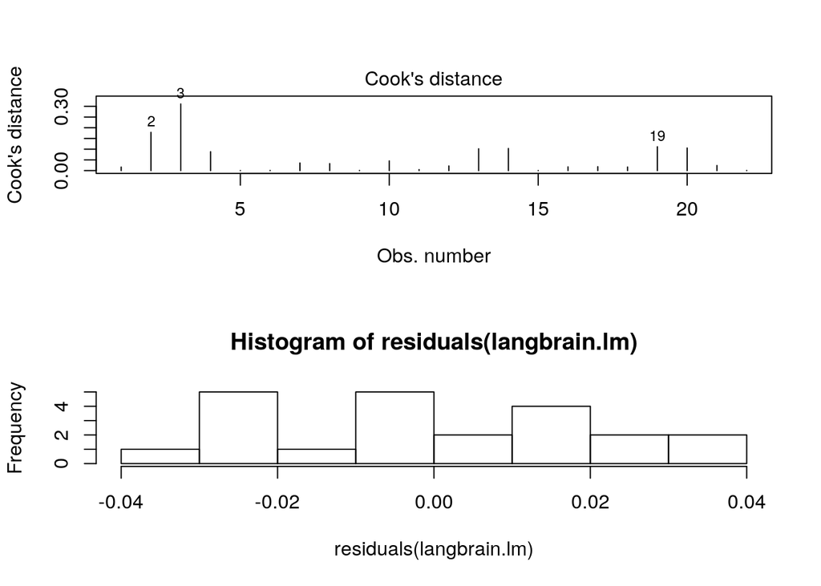

```r
plot(langbrain.lm, which=4)
hist(residuals(langbrain.lm))
```

# 15.b) Calculate the correlation between second language proficiency and gray-matter density.

```r
cor(greymat$proficiency, greymat$greymatter)
```

```
## [1] 0.8183134
```

# 15.c) Test the null hypothesis of zero correlation.

```r
cor.test(greymat$proficiency, greymat$greymatter)
```

```
##
##  Pearson's product-moment correlation
##
## data:  greymat$proficiency and greymat$greymatter
## t = 6.3671, df = 20, p-value = 3.264e-06
## alternative hypothesis: true correlation is not equal to 0
## 95 percent confidence interval:
##  0.6056638 0.9218696
## sample estimates:
##       cor
## 0.8183134
```

# 15.d) What are your assumptions in part (c)?

> 15.d) This test assumes that: i) The samples are randomly selected from a population ii) Each observation is independent iii) The sample data exhibits a linear (not polynomial, log, etc ) relationship. iii) The X and Y variables each independently exhibit a normal distribution.

# 15.e) Does the scatter plot support these assumptions? Explain.

> 15.e) The scatterplots support the previously described assumptions. The Q-Q plot does not exhibit a large deviation from normality. The scatterplot does not exhibit an obviously nonlinear relationship. The sample size isn’t enormous or incredibly low.

# 15.f) Do the results demonstrate that second language proficiency affects gray-matter density in the brain? Why or why not?

# 19) The following data are from a laboratory experiment by Smallwood et al. (1998) in which liver preparations from five rats were used to measure the relationship between the administered concentration of taurocholate (a salt normally occurring in liver bile) and the unbound fraction of taurocholate in the liver.

> 19.a) Calculate the correlation coefficient between the taurocholate unbound fraction and the concentration.

```r
liverprep<-read.csv("http://whitlockschluter.zoology.ubc.ca/wp-content/data/chapter16/chap16q19LiverPreparation.csv")
cor(liverprep$concentration, liverprep$unboundFraction)
```

```
## [1] -0.8563765
```

# 19.b) Plot the relationship between the two variables in a graph.

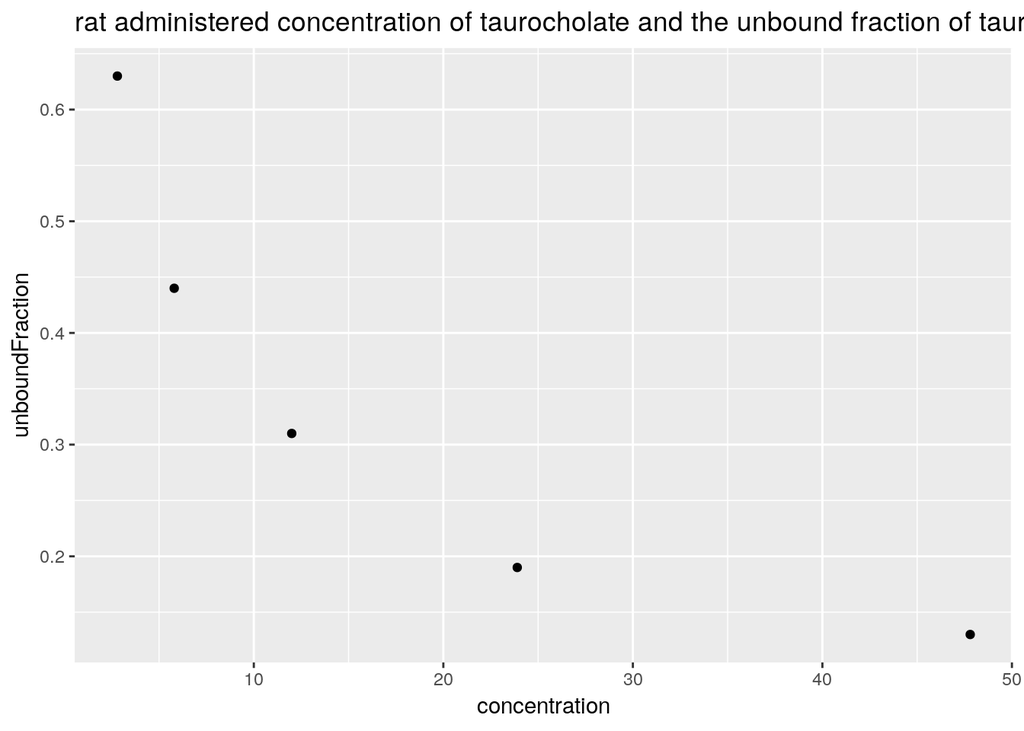

```r
ggplot(data=liverprep, aes(x=concentration, y=unboundFraction)) +
  geom_point()+
   ggtitle("rat administered concentration of taurocholate and the unbound fraction of taurocholate in the liver")
```

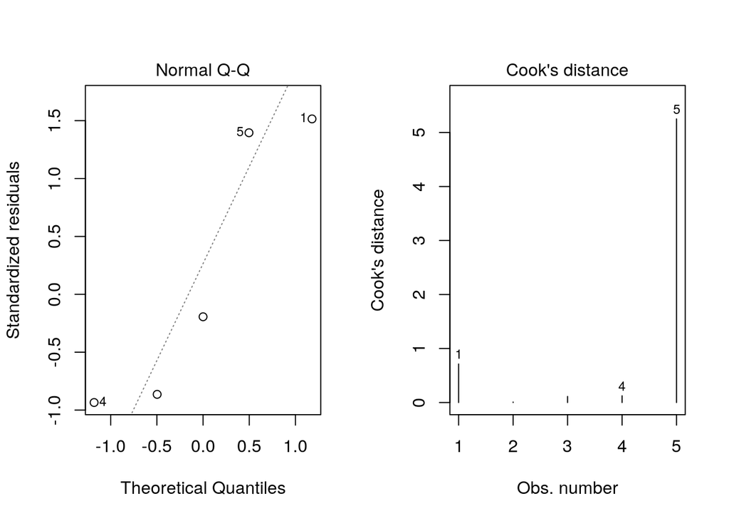

```r
conc.fract.lm<-lm(unboundFraction ~ concentration, data=liverprep)
par(mfrow = c(1,2))
plot(conc.fract.lm, which=2)
plot(conc.fract.lm, which=4)
```

```r
par(mfrow = c(1,1))
```

# 19.c) Examine the plot in part (b). The relationship appears to be maximally strong, yet the correlation coefficient you calculated in part (a) is not near the maximum possible value. Why not?

> 19.c) Answer: The relationship is negative rather than positive, the sample size is extremely low and there seems to be an outlier.

# 19.d) What steps would you take with these data to meet the assumptions of correlation analysis?

> 19.d) Answer: Given that the sample size is very low I would suggest increasing samples above all over options. Transforming the data doesnt solve the issue of small sample size but a nonparametric like the spearmans rank correlation could be used without a violation of assumptions.

# 2. Correlation SE

## Consider the following dataset:

```r
set.seed(20181011)
mat <- rmnorm(10, varcov = matrix(c(1,0.3, 0.3, 1), ncol=2)) %>%
  round(2) %>%
  as.data.frame %>%
  rename(cats = "V1", happiness_score = "V2")
mat
```

```
##     cats happiness_score
## 1  -0.30           -0.57
## 2   0.42           -0.10
## 3   0.85           -0.04
## 4  -0.45           -0.29
## 5   0.22            0.42
## 6  -0.12           -0.92
## 7   1.46            0.99
## 8  -0.79           -0.62
## 9   0.40            1.14
## 10 -0.07            0.33
```

## 2a. Are these two variables correlated? What is the output of `cor()` here. What does a test show you?

```r
cor(mat$cats, mat$happiness_score)
```

```
## [1] 0.6758738
```

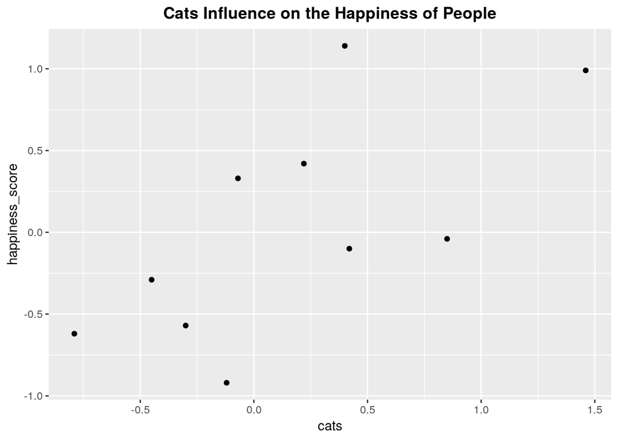

```r
# lineary model and visualization of qqplot and cook's distance
cathappy.lm<-lm(happiness_score ~ cats, data=mat)
ggplot(data=mat, aes(x=cats, y=happiness_score,))+
 geom_point()+
   ggtitle("Cats Influence on the Happiness of People")+
     theme(plot.title = element_text(lineheight=2, face="bold",hjust=.5))
```

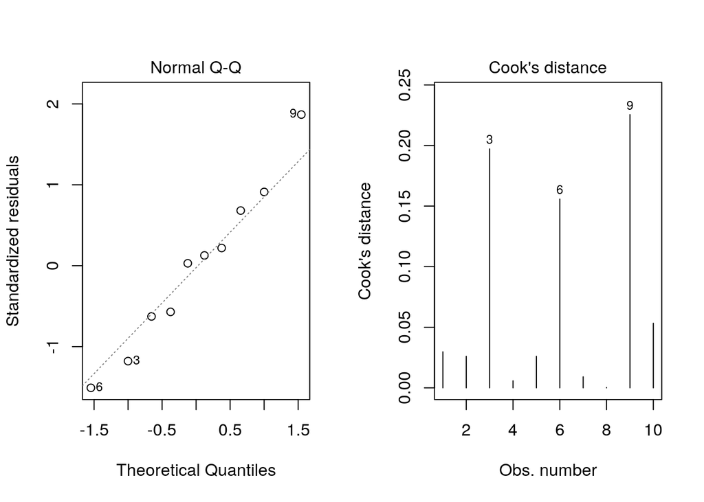

```r
par(mfrow = c(1,2))
plot(cathappy.lm, which=c(2,4))
```

```r
par(mfrow = c(1,1))
# testing via anova
anova(cathappy.lm)
```

```
## Analysis of Variance Table
##
## Response: happiness_score
##           Df Sum Sq Mean Sq F value  Pr(>F)
## cats       1 1.9208 1.92079  6.7277 0.03193 *
## Residuals  8 2.2841 0.28551
## ---
## Signif. codes:  0 '***' 0.001 '**' 0.01 '*' 0.05 '.' 0.1 ' ' 1
```

> 2b. What is the SE of the correlation based on the info from `cor.test()`

```r
catcor<-cor.test(mat$cats, mat$happiness_score)
catcor$estimate/catcor$statistic
sqrt((1-catcor$estimate^2)/(catcor$parameter))
sqrt((1-catcor$estimate^2)/(nrow(mat)-2))
```

[output not shown]

# 2c. Now, what is the SE via simulation? To do this, you’ll need to use `cor()` and get the relevant parameter from the output (remember - you get a matrix back, so, what’s the right index!), `replicate()`, and `sample()` or `dplyr::sample_n()` with `replace=TRUE` to get, let’s say, 1000 correlations. How does this compare to your value above?

```r
simfor.std.err.cor <- replicate(n=1000, expr=cor(sample_n(mat, nrow(mat), replace=TRUE)))
se.of.cor.sim<-sd(simfor.std.err.cor[1,2, 1:1000])
se.of.cor.sim
```

```
## [1] 0.1524226
```

```r
#comparison<-c(se.of.cor.sim/as.numeric(std.err.cortest))
```

# 3. W&S Chapter 17

> Questions 19, 30, 31

## 19) You might think that increasing the resources available would elevate the number of plant species that an area could support, but the evidence suggests otherwise. The data in the accompanying table are from the Park Grass Experiment at Rothamsted Experimental Station in the U.K., where grassland field plots have been fertilized annually for the past 150 years (collated by Harpole and Tilman 2007). The number of plant species recorded in 10 plots is given in response to the number of different nutrient types added in the fertilizer treatment (nutrient types include nitrogen, phosphorus, potassium, and so on).

## 19.a) Draw a scatter plot of these data. Which variable should be the explanatory variable (X), and which should be the response variable (Y)?

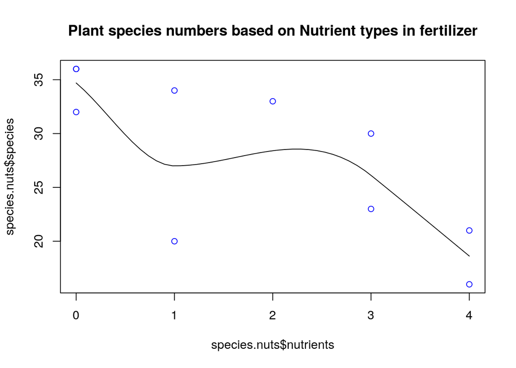

```r
species.nuts<-read.csv("http://whitlockschluter.zoology.ubc.ca/wp-content/data/chapter17/chap17q19GrasslandNutrientsPlantSpecies.csv")

scatter.smooth(species.nuts$species ~ species.nuts$nutrients,main="Plant species numbers based on Nutrient types in fertilizer", col=c("blue"))
```

## 19.b) What is the rate of change in the number of plant species supported per nutrient type added? Provide a standard error for your estimate.

```r
species.nutrients.lm <- lm(species ~ nutrients, data=species.nuts)
rate.of.delta<-species.nutrients.lm$coefficients

secies.nutrients.lm.sum<-summary(species.nutrients.lm)
secies.nutrients.lm.Rdub<-summary(species.nutrients.lm)$r.squared
secies.nutrients.lm.Rdub
```

```
## [1] 0.5359785
```

```r
std.err.delta<-secies.nutrients.lm.sum$coefficients[2,"Std. Error"]

print(paste("The rate of change is ", rate.of.delta[2], "and its standard error is ", std.err.delta))
```

```
## [1] "The rate of change is  -3.33898305084746 and its standard error is  1.09841019454144"
```

## 19.c) Add the least-squares regression line to your scatter plot. What fraction of the variation in the number of plant species is “explained” by the number of nutrients added?

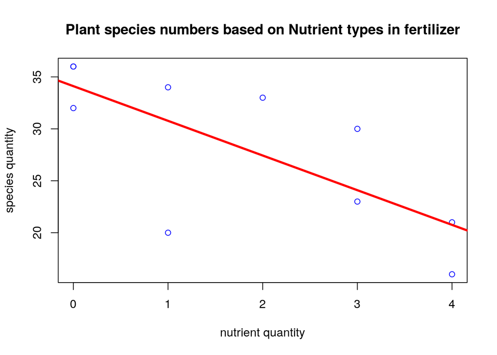

```r
int.slope<-species.nutrients.lm$coefficients
intercept<-as.numeric(int.slope[1])
rate.of.delta<-as.numeric(int.slope[2])
plot(y=species.nuts$species, x=species.nuts$nutrients,main="Plant species numbers based on Nutrient types in fertilizer", xlab="nutrient quantity", ylab="species quantity", col="blue")
abline(intercept,rate.of.delta, col=2,lwd=3)
```

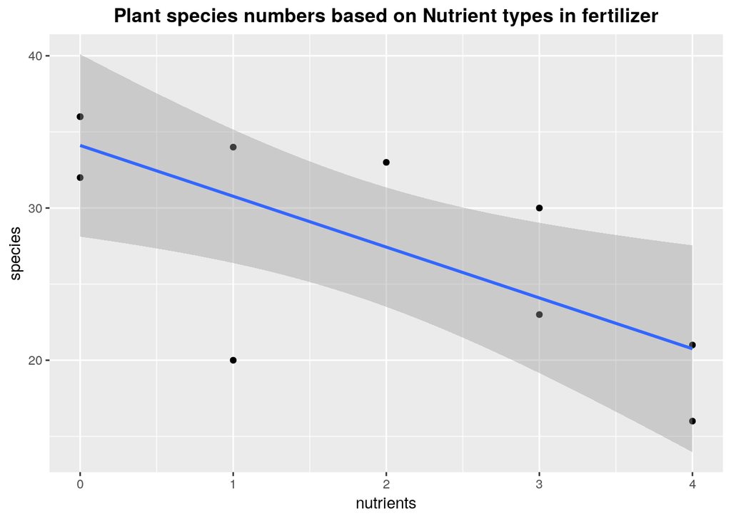

```r
ggplot(data=species.nuts, aes(y=species, x=nutrients))+
  geom_point()+
     ggtitle("Plant species numbers based on Nutrient types in fertilizer")+
     theme(plot.title = element_text(lineheight=2, face="bold",hjust=.5))+
                stat_smooth(method="lm", formula=y~x)
```

```r
cor(y=species.nuts$species, x=species.nuts$nutrients)
```

```
## [1] -0.7321056
```